# Quick Data Visualization

Renata

2024-07-25

##Set-up

```r
ChicagoData <- read.csv("./ChicagoSegmentData.csv")
DurhamData <- read.csv("./DurhamSegmentData.csv")
```

###Look at Census data

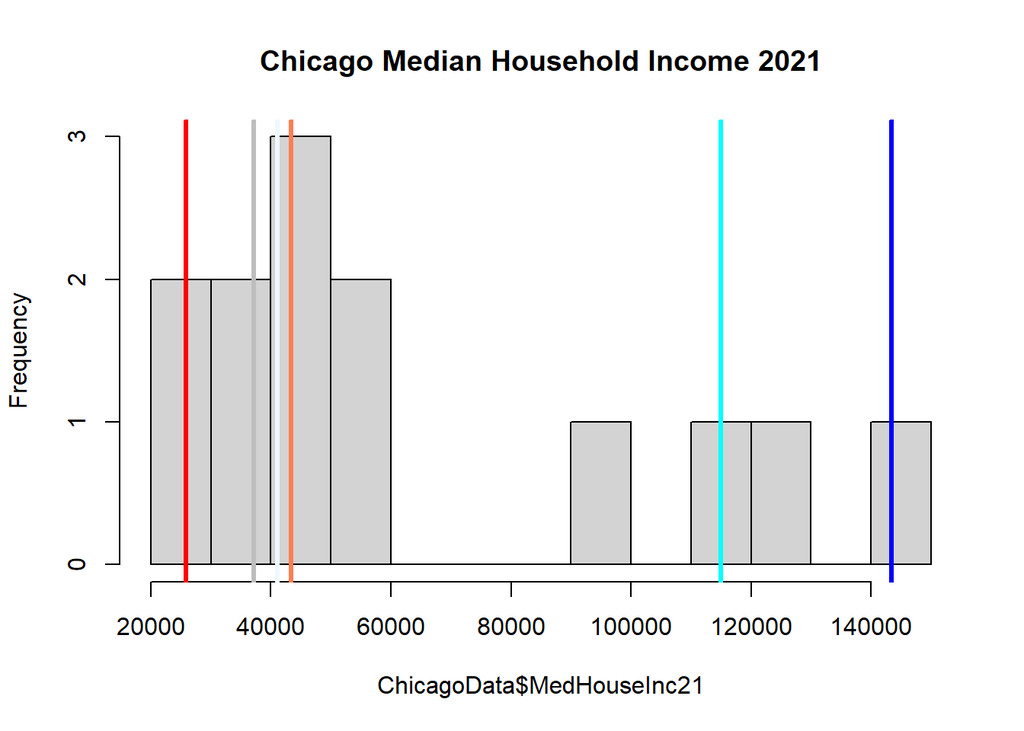

```r
##case study areas - Chicago
Cgr1 <- c(324, 292) #high construction - perhaps a bit too different
Cgr2 <- c(16, 244) #moderate construction
Cgr3 <- c(49, 57) #low construction
ChiCaseStudyData1 <- ChicagoData[ChicagoData$Segment %in% Cgr1,] #blues
ChiCaseStudyData2 <- ChicagoData[ChicagoData$Segment %in% Cgr2,] #reds
ChiCaseStudyData3 <- ChicagoData[ChicagoData$Segment %in% Cgr3,] #silvers

#####case study areas - Durham
#######NEED TO RE-DO
Dgr1 <- c("M22", "M19") #moderate construction
Dgr2 <- c("M22", "R24")  #moderate construction but have big SVI contrast too :/
Dgr3 <- c("U17", "S19")  #moderate construction

DurCaseStudyData1 <- DurhamData[DurhamData$Segment %in% Dgr1,] #greens
DurCaseStudyData2 <- DurhamData[DurhamData$Segment %in% Dgr2,] #purples
DurCaseStudyData3 <- DurhamData[DurhamData$Segment %in% Dgr3,] #yellows

#############Median Household Income
hist(ChicagoData$MedHouseInc21, breaks = 15, main="Chicago Median Household Income 2021")
abline(v=ChiCaseStudyData1$MedHouseInc21[1], col="cyan", lwd=3)
abline(v=ChiCaseStudyData1$MedHouseInc21[2], col="blue", lwd=3)
abline(v=ChiCaseStudyData2$MedHouseInc21[1], col="coral", lwd=3)
abline(v=ChiCaseStudyData2$MedHouseInc21[2], col="red", lwd=3)
abline(v=ChiCaseStudyData3$MedHouseInc21[1], col="aliceblue", lwd=3)
abline(v=ChiCaseStudyData3$MedHouseInc21[2], col="gray", lwd=3)
```

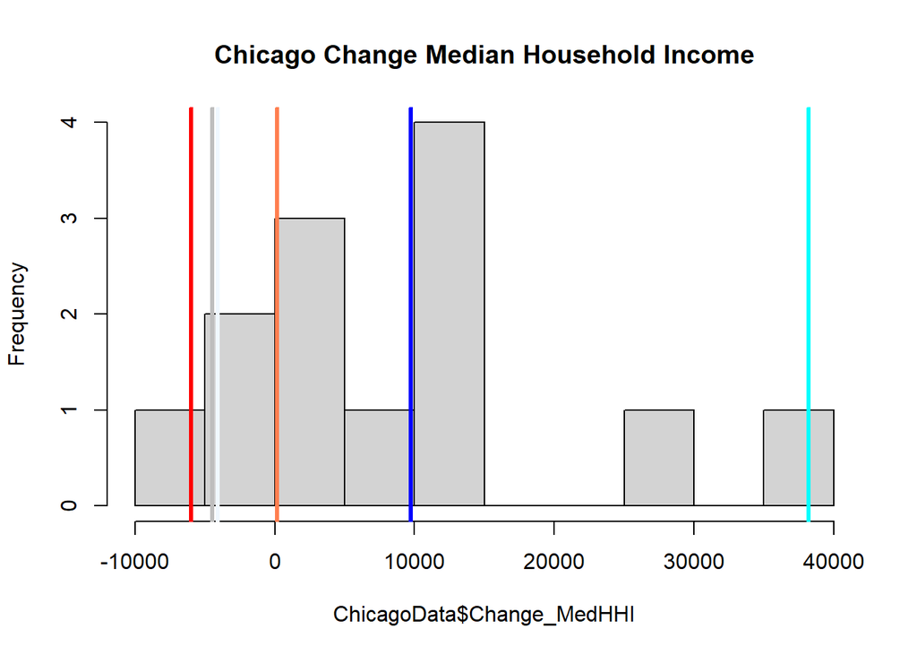

```r
hist(ChicagoData$Change_MedHHI, breaks = 10, main="Chicago Change Median Household Income")
abline(v=ChiCaseStudyData1$Change_MedHHI[1], col="cyan", lwd=3)
abline(v=ChiCaseStudyData1$Change_MedHHI[2], col="blue", lwd=3)
abline(v=ChiCaseStudyData2$Change_MedHHI[1], col="coral", lwd=3)
abline(v=ChiCaseStudyData2$Change_MedHHI[2], col="red", lwd=3)
abline(v=ChiCaseStudyData3$Change_MedHHI[1], col="aliceblue", lwd=3)
abline(v=ChiCaseStudyData3$Change_MedHHI[2], col="grey", lwd=3)
```

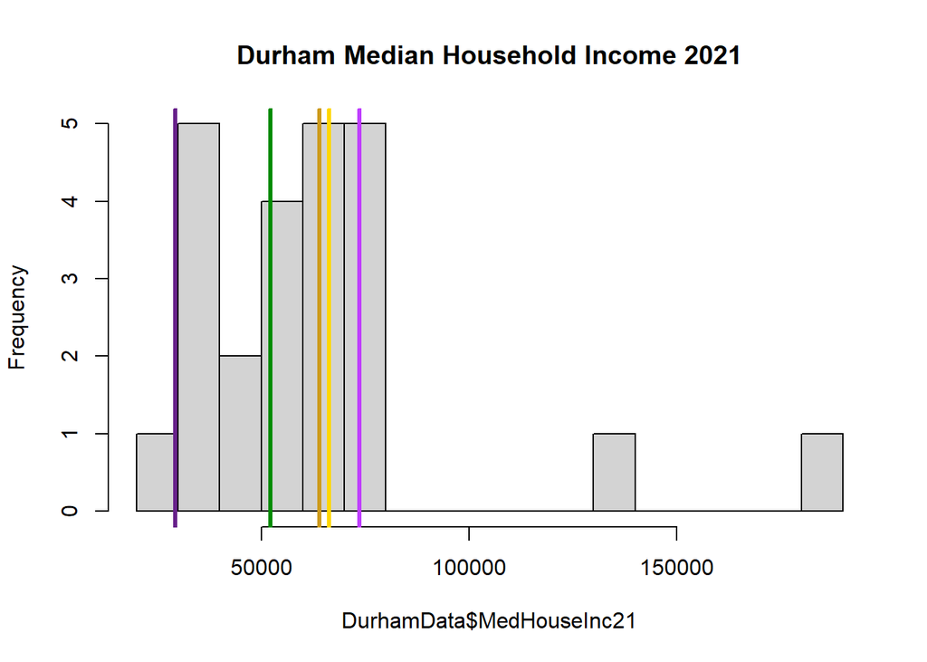

```r
hist(DurhamData$MedHouseInc21, breaks = 20, main="Durham Median Household Income 2021")
abline(v=DurCaseStudyData1$MedHouseInc21[1], col="springgreen", lwd=3)
abline(v=DurCaseStudyData1$MedHouseInc21[2], col="green4", lwd=3)
abline(v=DurCaseStudyData2$MedHouseInc21[1], col="darkorchid1", lwd=3)
abline(v=DurCaseStudyData2$MedHouseInc21[2], col="darkorchid4", lwd=3)
abline(v=DurCaseStudyData3$MedHouseInc21[1], col="gold", lwd=3)
abline(v=DurCaseStudyData3$MedHouseInc21[2], col="goldenrod3", lwd=3)
```

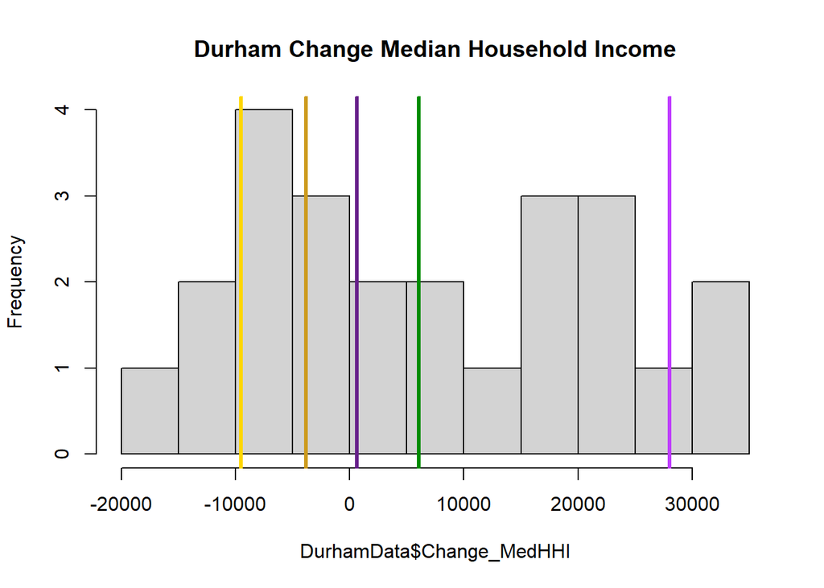

```r
hist(DurhamData$Change_MedHHI, breaks = 10, main="Durham Change Median Household Income")
abline(v=DurCaseStudyData1$Change_MedHHI[1], col="springgreen", lwd=3)
abline(v=DurCaseStudyData1$Change_MedHHI[2], col="green4", lwd=3)
abline(v=DurCaseStudyData2$Change_MedHHI[1], col="darkorchid1", lwd=3)
abline(v=DurCaseStudyData2$Change_MedHHI[2], col="darkorchid4", lwd=3)
abline(v=DurCaseStudyData3$Change_MedHHI[1], col="gold", lwd=3)
abline(v=DurCaseStudyData3$Change_MedHHI[2], col="goldenrod3", lwd=3)
```

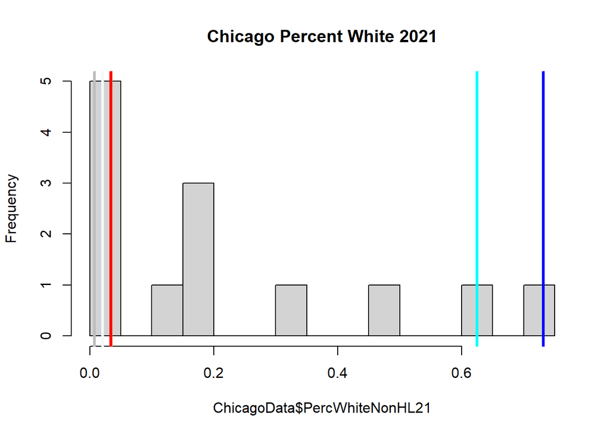

```r
#############Percent White non-HL
hist(ChicagoData$PercWhiteNonHL21, breaks = 15, main="Chicago Percent White 2021")
abline(v=ChiCaseStudyData1$PercWhiteNonHL21[1], col="cyan", lwd=3)
abline(v=ChiCaseStudyData1$PercWhiteNonHL21[2], col="blue", lwd=3)
abline(v=ChiCaseStudyData2$PercWhiteNonHL21[1], col="coral", lwd=3)
abline(v=ChiCaseStudyData2$PercWhiteNonHL21[2], col="red", lwd=3)
abline(v=ChiCaseStudyData3$PercWhiteNonHL21[1], col="aliceblue", lwd=3)
abline(v=ChiCaseStudyData3$PercWhiteNonHL21[2], col="grey", lwd=3)
```

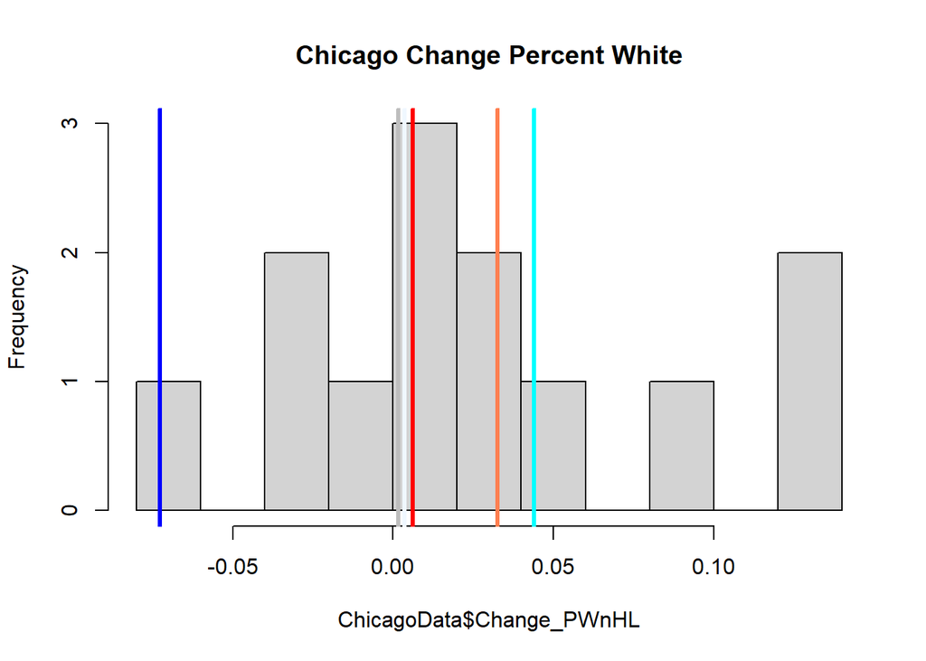

```r
hist(ChicagoData$Change_PWnHL, breaks = 10, main="Chicago Change Percent White")
abline(v=ChiCaseStudyData1$Change_PWnHL[1], col="cyan", lwd=3)
abline(v=ChiCaseStudyData1$Change_PWnHL[2], col="blue", lwd=3)
abline(v=ChiCaseStudyData2$Change_PWnHL[1], col="coral", lwd=3)
abline(v=ChiCaseStudyData2$Change_PWnHL[2], col="red", lwd=3)
abline(v=ChiCaseStudyData3$Change_PWnHL[1], col="aliceblue", lwd=3)
abline(v=ChiCaseStudyData3$Change_PWnHL[2], col="grey", lwd=3)
```

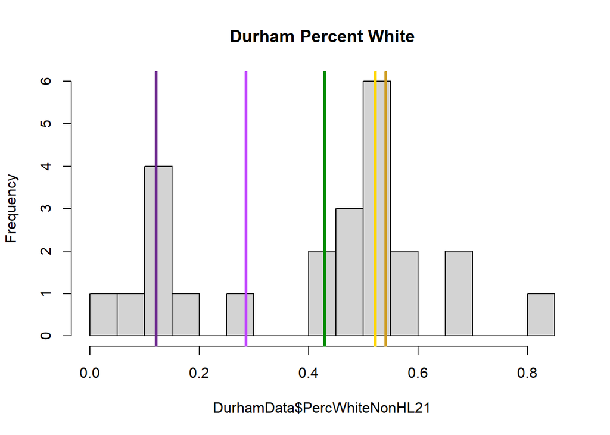

```r
hist(DurhamData$PercWhiteNonHL21, breaks = 20, main="Durham Percent White")
abline(v=DurCaseStudyData1$PercWhiteNonHL21[1], col="springgreen", lwd=3)
abline(v=DurCaseStudyData1$PercWhiteNonHL21[2], col="green4", lwd=3)
abline(v=DurCaseStudyData2$PercWhiteNonHL21[1], col="darkorchid1", lwd=3)
abline(v=DurCaseStudyData2$PercWhiteNonHL21[2], col="darkorchid4", lwd=3)
abline(v=DurCaseStudyData3$PercWhiteNonHL21[1], col="gold", lwd=3)
abline(v=DurCaseStudyData3$PercWhiteNonHL21[2], col="goldenrod3", lwd=3)
```

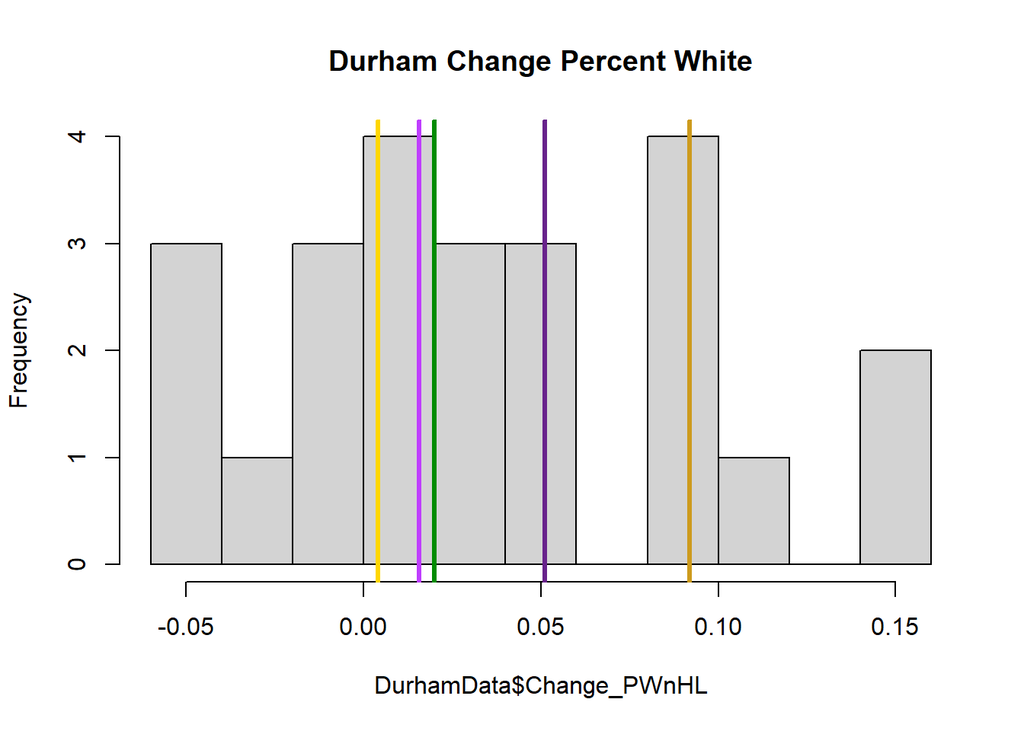

```r
hist(DurhamData$Change_PWnHL, breaks = 10, main="Durham Change Percent White")
abline(v=DurCaseStudyData1$Change_PWnHL[1], col="springgreen", lwd=3)
abline(v=DurCaseStudyData1$Change_PWnHL[2], col="green4", lwd=3)
abline(v=DurCaseStudyData2$Change_PWnHL[1], col="darkorchid1", lwd=3)
abline(v=DurCaseStudyData2$Change_PWnHL[2], col="darkorchid4", lwd=3)
abline(v=DurCaseStudyData3$Change_PWnHL[1], col="gold", lwd=3)
abline(v=DurCaseStudyData3$Change_PWnHL[2], col="goldenrod3", lwd=3)
```

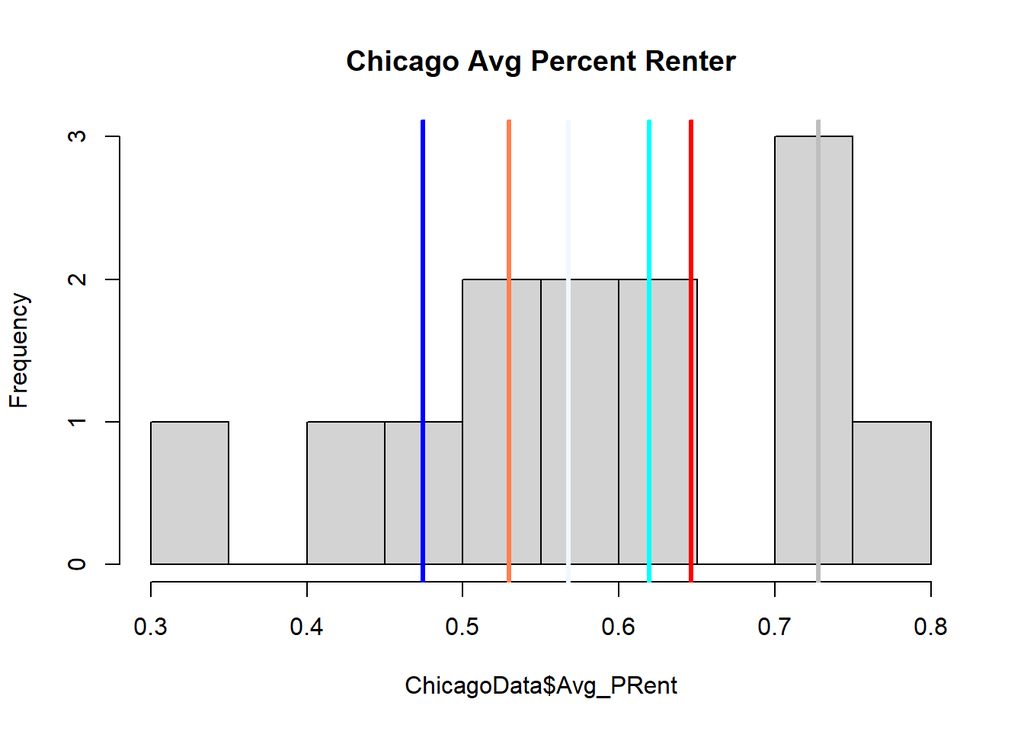

```r
###################Average Percent Renter
hist(ChicagoData$Avg_PRent, breaks = 10, main="Chicago Avg Percent Renter")
abline(v=ChiCaseStudyData1$Avg_PRent[1], col="cyan", lwd=3)
abline(v=ChiCaseStudyData1$Avg_PRent[2], col="blue", lwd=3)
abline(v=ChiCaseStudyData2$Avg_PRent[1], col="coral", lwd=3)
abline(v=ChiCaseStudyData2$Avg_PRent[2], col="red", lwd=3)
abline(v=ChiCaseStudyData3$Avg_PRent[1], col="aliceblue", lwd=3)
abline(v=ChiCaseStudyData3$Avg_PRent[2], col="grey", lwd=3)
```

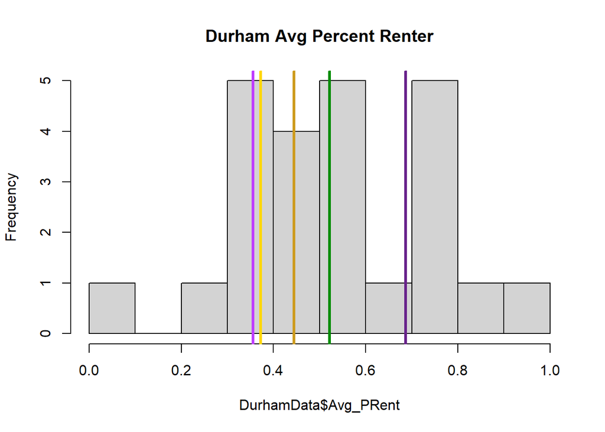

```r
hist(DurhamData$Avg_PRent, breaks = 10, main="Durham Avg Percent Renter")
abline(v=DurCaseStudyData1$Avg_PRent[1], col="springgreen", lwd=3)
abline(v=DurCaseStudyData1$Avg_PRent[2], col="green4", lwd=3)
abline(v=DurCaseStudyData2$Avg_PRent[1], col="darkorchid1", lwd=3)
abline(v=DurCaseStudyData2$Avg_PRent[2], col="darkorchid4", lwd=3)
abline(v=DurCaseStudyData3$Avg_PRent[1], col="gold", lwd=3)
abline(v=DurCaseStudyData3$Avg_PRent[2], col="goldenrod3", lwd=3)
```

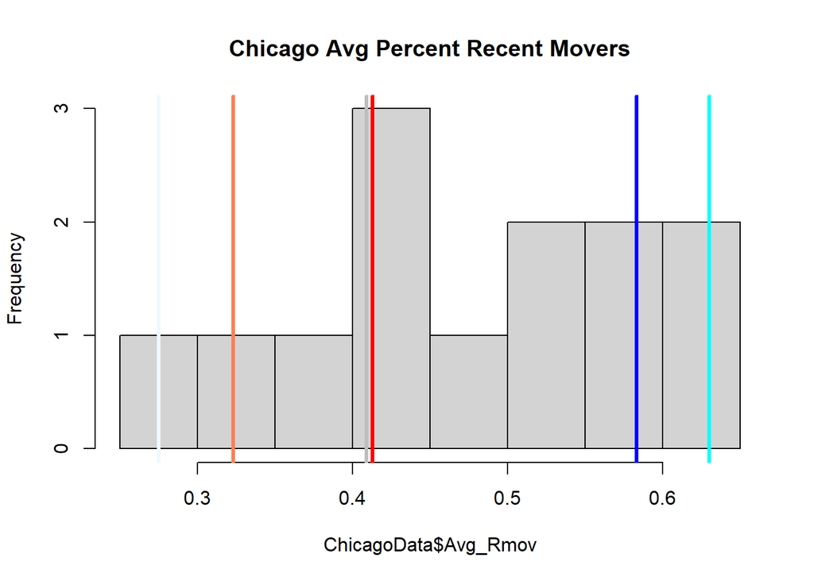

```r
####################Average Recent Movers
hist(ChicagoData$Avg_Rmov, breaks = 10, main="Chicago Avg Percent Recent Movers")
abline(v=ChiCaseStudyData1$Avg_Rmov[1], col="cyan", lwd=3)
abline(v=ChiCaseStudyData1$Avg_Rmov[2], col="blue", lwd=3)
abline(v=ChiCaseStudyData2$Avg_Rmov[1], col="coral", lwd=3)
abline(v=ChiCaseStudyData2$Avg_Rmov[2], col="red", lwd=3)
abline(v=ChiCaseStudyData3$Avg_Rmov[1], col="aliceblue", lwd=3)
abline(v=ChiCaseStudyData3$Avg_Rmov[2], col="grey", lwd=3)
```

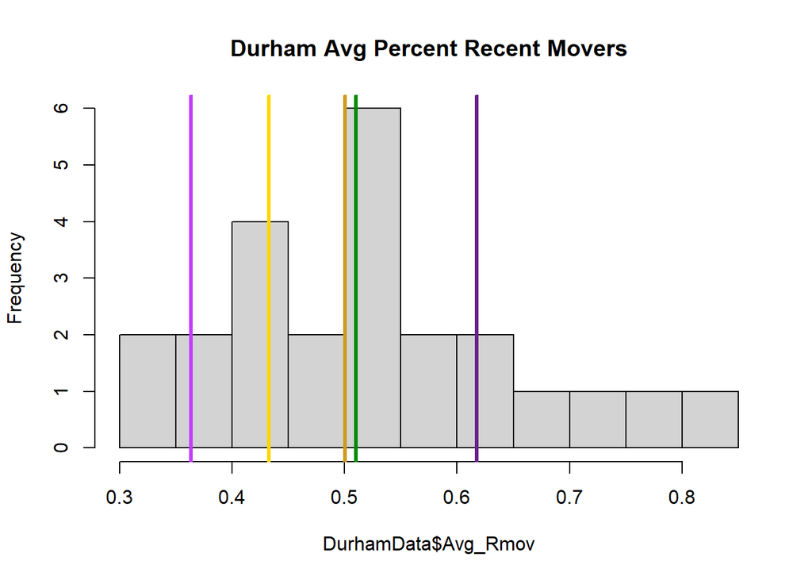

```r
hist(DurhamData$Avg_Rmov, breaks = 10, main="Durham Avg Percent Recent Movers")
abline(v=DurCaseStudyData1$Avg_Rmov[1], col="springgreen", lwd=3)
abline(v=DurCaseStudyData1$Avg_Rmov[2], col="green4", lwd=3)
abline(v=DurCaseStudyData2$Avg_Rmov[1], col="darkorchid1", lwd=3)
abline(v=DurCaseStudyData2$Avg_Rmov[2], col="darkorchid4", lwd=3)
abline(v=DurCaseStudyData3$Avg_Rmov[1], col="gold", lwd=3)
abline(v=DurCaseStudyData3$Avg_Rmov[2], col="goldenrod3", lwd=3)
```

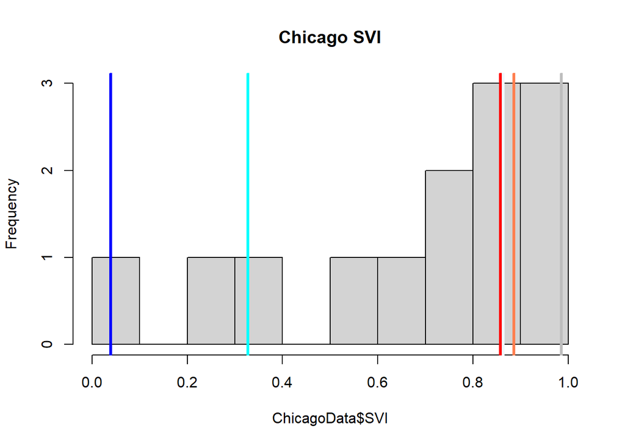

```r
######################SVI
hist(ChicagoData$SVI, breaks = 10, main="Chicago SVI")
abline(v=ChiCaseStudyData1$SVI[1], col="cyan", lwd=3)
abline(v=ChiCaseStudyData1$SVI[2], col="blue", lwd=3)
abline(v=ChiCaseStudyData2$SVI[1], col="coral", lwd=3)
abline(v=ChiCaseStudyData2$SVI[2], col="red", lwd=3)
abline(v=ChiCaseStudyData3$SVI[1], col="aliceblue", lwd=3)
abline(v=ChiCaseStudyData3$SVI[2], col="grey", lwd=3)
```

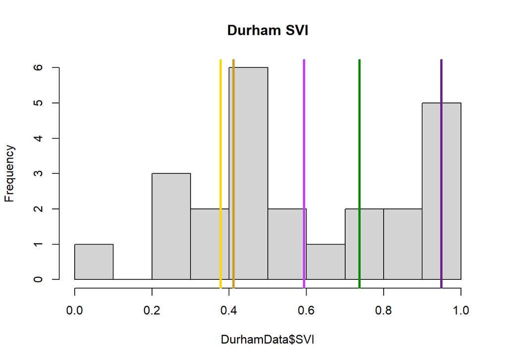

```r
hist(DurhamData$SVI, breaks = 10, main="Durham SVI")
abline(v=DurCaseStudyData1$SVI[1], col="springgreen", lwd=3)
abline(v=DurCaseStudyData1$SVI[2], col="green4", lwd=3)
abline(v=DurCaseStudyData2$SVI[1], col="darkorchid1", lwd=3)
abline(v=DurCaseStudyData2$SVI[2], col="darkorchid4", lwd=3)
abline(v=DurCaseStudyData3$SVI[1], col="gold", lwd=3)
abline(v=DurCaseStudyData3$SVI[2], col="goldenrod3", lwd=3)
```

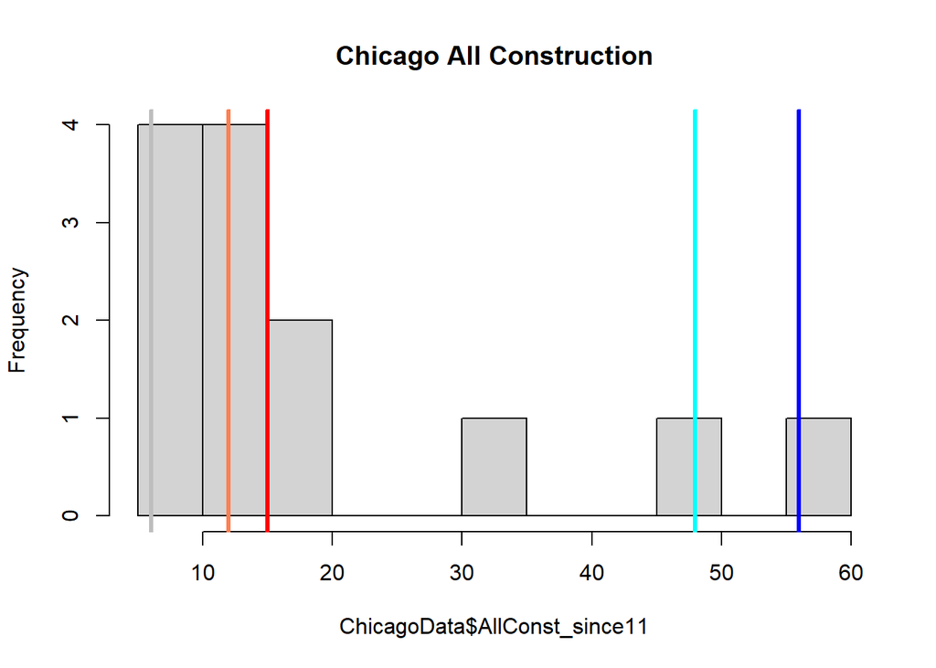

```r
####################Construction
hist(ChicagoData$AllConst_since11, breaks = 10, main="Chicago All Construction")
abline(v=ChiCaseStudyData1$AllConst_since11[1], col="cyan", lwd=3)
abline(v=ChiCaseStudyData1$AllConst_since11[2], col="blue", lwd=3)
abline(v=ChiCaseStudyData2$AllConst_since11[1], col="coral", lwd=3)
abline(v=ChiCaseStudyData2$AllConst_since11[2], col="red", lwd=3)
abline(v=ChiCaseStudyData3$AllConst_since11[1], col="aliceblue", lwd=3)
abline(v=ChiCaseStudyData3$AllConst_since11[2], col="grey", lwd=3)
```

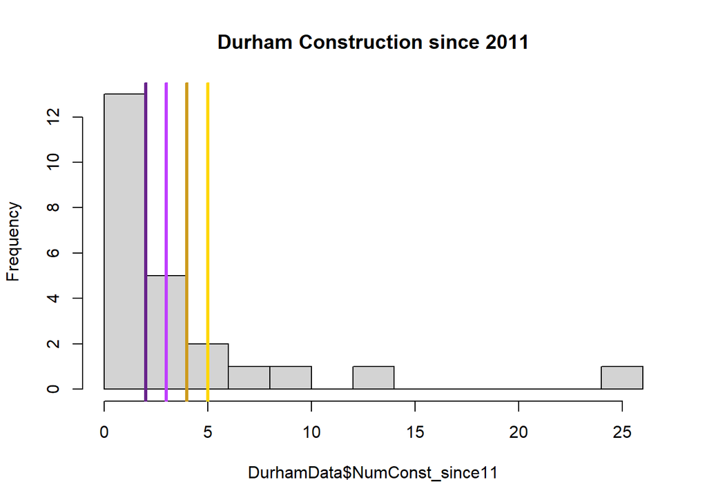

```r
hist(DurhamData$NumConst_since11, breaks = 10, main="Durham Construction since 2011")
abline(v=DurCaseStudyData1$NumConst_since11[1], col="springgreen", lwd=3)
abline(v=DurCaseStudyData1$NumConst_since11[2], col="green4", lwd=3)
abline(v=DurCaseStudyData2$NumConst_since11[1], col="darkorchid1", lwd=3)
abline(v=DurCaseStudyData2$NumConst_since11[2], col="darkorchid4", lwd=3)
abline(v=DurCaseStudyData3$NumConst_since11[1], col="gold", lwd=3)
abline(v=DurCaseStudyData3$NumConst_since11[2], col="goldenrod3", lwd=3)
```

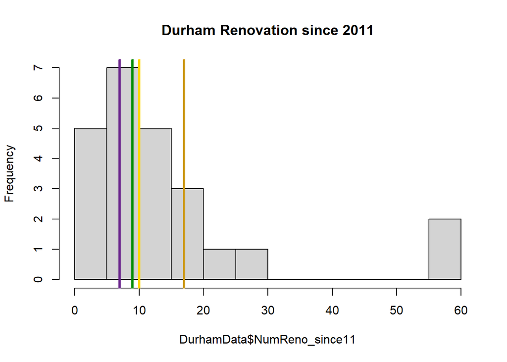

```r
hist(DurhamData$NumReno_since11, breaks = 10, main="Durham Renovation since 2011")
abline(v=DurCaseStudyData1$NumReno_since11[1], col="springgreen", lwd=3)
abline(v=DurCaseStudyData1$NumReno_since11[2], col="green4", lwd=3)
abline(v=DurCaseStudyData2$NumReno_since11[1], col="darkorchid1", lwd=3)
abline(v=DurCaseStudyData2$NumReno_since11[2], col="darkorchid4", lwd=3)
abline(v=DurCaseStudyData3$NumReno_since11[1], col="gold", lwd=3)
abline(v=DurCaseStudyData3$NumReno_since11[2], col="goldenrod3", lwd=3)
```

##Notes

Chicago * blues - both on upper end of 2021 income, but huge gap in change in income over time (though both on upper end) - both on upper end of percent white 2021, but light had a big increase while dark did not - towards the middle, though have a solid gap in % renter - not a huge gap in recent movers, both on the high end - bit of a gap in SVI, though both relatively low - upper end of construction; a bit of a gap but not out of reason

- reds
- both on lower end of 2021 income, a bit of a gap in change in income but not huge
- close on percent white (I think, coral is masked under something else) in 2021. Bit more of a gap in change but near middle
- towards the middle with solid gap in % renter
- solid gap in recent movers, towards the lower/middle of the range
- close on SVI on the upper end
- close on construction
- greys
- close together in 2021 income and on change in income
- close on percent white 2021 and in change
- big gap in % renter, dark much higher
- on lower end of recent movers but have a solid gap
- a bit of a gap on SVI (though not huge), both on the upper end
- I think identical construction? unclear the light is masked under something

Maybe focus on greys and reds for the rest of it

Durham - recall that light green and light purple are the same segment

- greens
- small ish gap in 2021 income, middle-ish; decent gap in change, though not as bad as purples
- near the middle on percent white, a gap but not horrible (2021), very similar change
- moderate gap in % renter, near the middle
- solid gap in % recent movers, but not as big as the purples
- SVI is similer, near the uppder-middle
- construction is close
- renos are close
- purples
- decent gap in 2021 income, pretty big gap in change in income (near zero/the middle and near the top)
- moderate gap in percent white in 2021, middle ot low, but only moderate gap in change (near middle)
- pretty decent gap in % renter
- big gap in % recent movers
- decent gap in SVI, upper end
- construction is close
- renos are close
- yellows
- very similar 2021 income, similar ish change in income
- simiar percent white, upper-middle in 2021, but have a solid gap in the change, dark on the upper end
- small gap in % renter, near middle
- moderate gap in recent movers, near middle
- very similar SVI
- construction is close
- bit more of a gap in renovations, but both in the upper middle

Maybe focus on greens and yellows for Durham?

##look at tree health outcomes

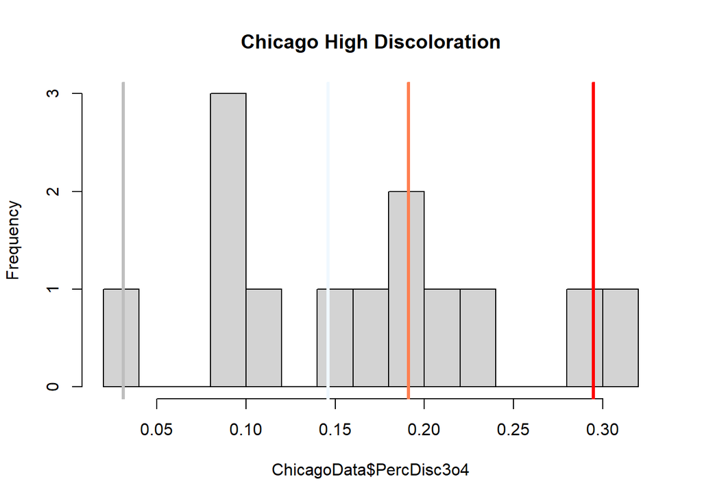

```r
##case study areas - Chicago
Cgr2 <- c(16, 244) #moderate construction
Cgr3 <- c(49, 57) #low construction

ChiCaseStudyData2 <- ChicagoData[ChicagoData$Segment %in% Cgr2,] #reds
ChiCaseStudyData3 <- ChicagoData[ChicagoData$Segment %in% Cgr3,] #silvers

#####case study areas - Durham
#######NEED TO RE-DO
Dgr1 <- c("M22", "M19") #moderate construction
Dgr3 <- c("U17", "S19")  #moderate construction

DurCaseStudyData1 <- DurhamData[DurhamData$Segment %in% Dgr1,] #greens
DurCaseStudyData3 <- DurhamData[DurhamData$Segment %in% Dgr3,] #yellows


########################Discoloration
hist(ChicagoData$PercDisc3o4, breaks = 10, main="Chicago High Discoloration")
abline(v=ChiCaseStudyData2$PercDisc3o4[1], col="coral", lwd=3)
abline(v=ChiCaseStudyData2$PercDisc3o4[2], col="red", lwd=3)
abline(v=ChiCaseStudyData3$PercDisc3o4[1], col="aliceblue", lwd=3)
abline(v=ChiCaseStudyData3$PercDisc3o4[2], col="grey", lwd=3)
```

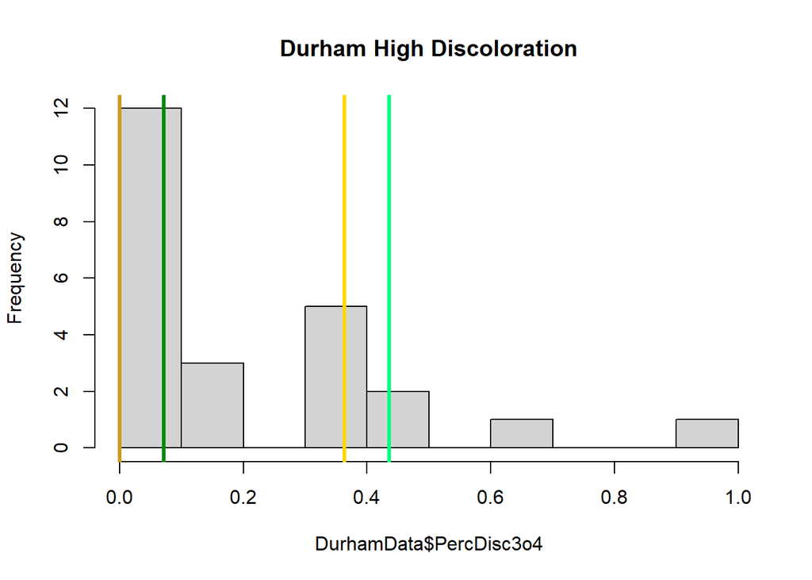

```r
hist(DurhamData$PercDisc3o4, breaks = 10, main="Durham High Discoloration")
abline(v=DurCaseStudyData1$PercDisc3o4[1], col="springgreen", lwd=3)
abline(v=DurCaseStudyData1$PercDisc3o4[2], col="green4", lwd=3)
abline(v=DurCaseStudyData3$PercDisc3o4[1], col="gold", lwd=3)
abline(v=DurCaseStudyData3$PercDisc3o4[2], col="goldenrod3", lwd=3)
```

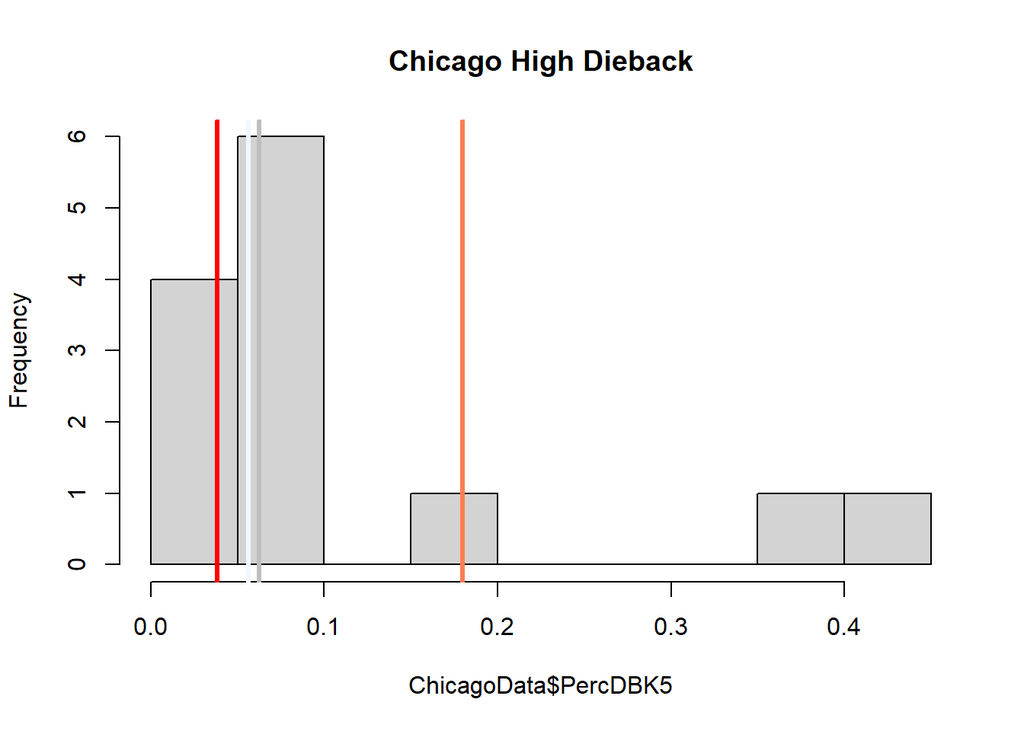

```r
###########################Dieback
hist(ChicagoData$PercDBK5, breaks = 10, main="Chicago High Dieback")
abline(v=ChiCaseStudyData2$PercDBK5[1], col="coral", lwd=3)
abline(v=ChiCaseStudyData2$PercDBK5[2], col="red", lwd=3)
abline(v=ChiCaseStudyData3$PercDBK5[1], col="aliceblue", lwd=3)
abline(v=ChiCaseStudyData3$PercDBK5[2], col="grey", lwd=3)
```

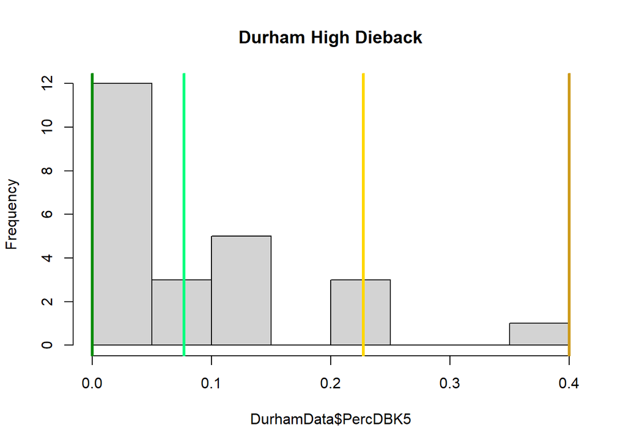

```r
hist(DurhamData$PercDBK5, breaks = 10, main="Durham High Dieback")
abline(v=DurCaseStudyData1$PercDBK5[1], col="springgreen", lwd=3)
abline(v=DurCaseStudyData1$PercDBK5[2], col="green4", lwd=3)
abline(v=DurCaseStudyData3$PercDBK5[1], col="gold", lwd=3)
abline(v=DurCaseStudyData3$PercDBK5[2], col="goldenrod3", lwd=3)
```

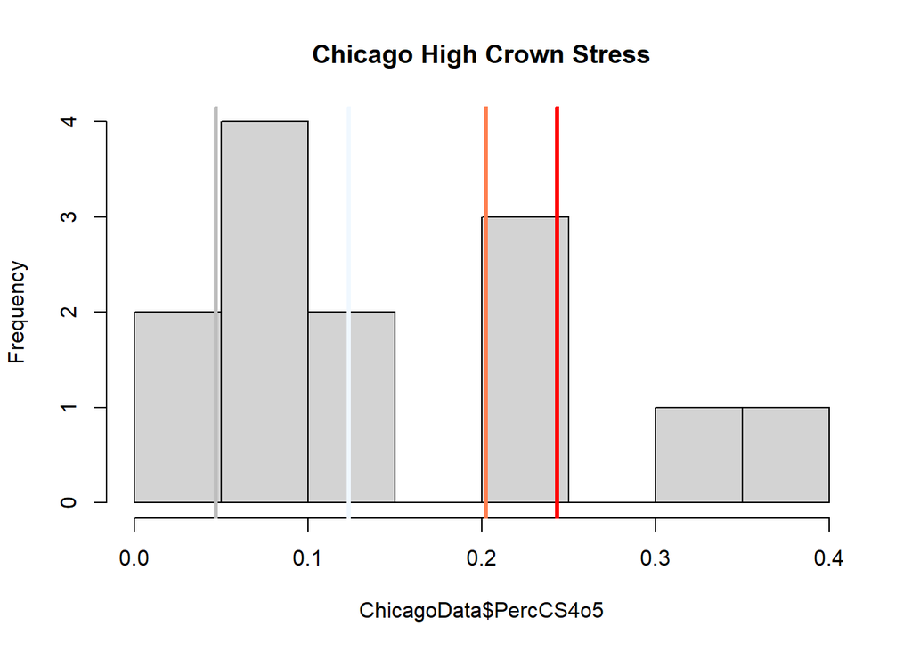

```r
###########################Crown Stress
hist(ChicagoData$PercCS4o5, breaks = 10, main="Chicago High Crown Stress")
abline(v=ChiCaseStudyData2$PercCS4o5[1], col="coral", lwd=3)
abline(v=ChiCaseStudyData2$PercCS4o5[2], col="red", lwd=3)
abline(v=ChiCaseStudyData3$PercCS4o5[1], col="aliceblue", lwd=3)
abline(v=ChiCaseStudyData3$PercCS4o5[2], col="grey", lwd=3)
```

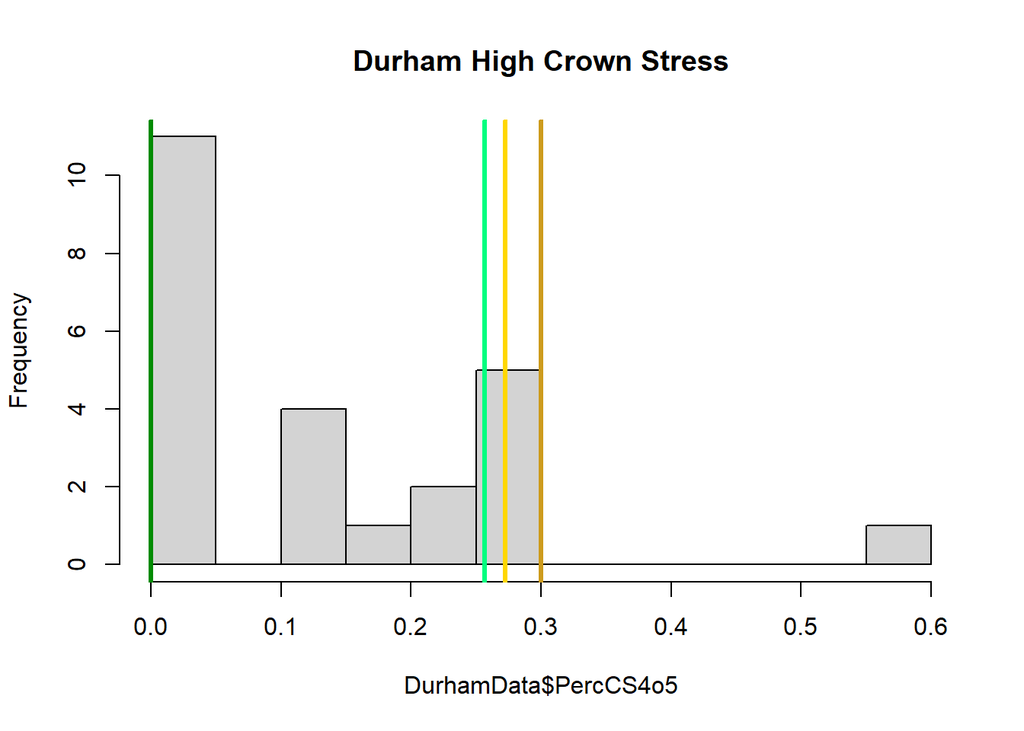

```r
hist(DurhamData$PercCS4o5, breaks = 10, main="Durham High Crown Stress")
abline(v=DurCaseStudyData1$PercCS4o5[1], col="springgreen", lwd=3)
abline(v=DurCaseStudyData1$PercCS4o5[2], col="green4", lwd=3)
abline(v=DurCaseStudyData3$PercCS4o5[1], col="gold", lwd=3)
abline(v=DurCaseStudyData3$PercCS4o5[2], col="goldenrod3", lwd=3)
```